# Estudios de Informática, Multimedia y Telecomunicaciones

# Estadística Avançada

Autor: Jordi Puig Ovejero

Març 2021

Carrega de les llibreries que es necessiten

```r
library(dplyr)
library(base)
library(matrixStats)
library(stringr)
library(ggplot2)
library(lubridate)
library(eeptools)
library(psych)
library(corrplot)
library(factoextra)
library(ggbiplot)
library(ggpubr)
library(rlang)
library(kableExtra)
```

# 1 Lectura del fitxer

El fitxer on es troba el dataset és, **fifa_clean.csv**:

Carreguem les dades i fem un summary d’aquestes tal i com que ens demana l’activitat.

```r
fifa <- read.csv('fifa_clean.csv',stringsAsFactors = TRUE, sep = ',')
fifa.tmp <- fifa[,c('Name', 'Nationality', 'National_Position', 'National_Kit', 'Club', 'Club_Position', 'Club_Kit', 'Club_Joining', 'Contract_Expiry', 'Rating', 'Height', 'Weight', 'Preffered_Foot', 'Birth_Date', 'Age', 'Preffered_Position', 'Work_Rate', 'Weak_foot' , 'Skill_Moves')]

attach(fifa) # ens permet referenciar les columnes de fifa sense haver d'especificar el dataset.

summary(fifa.tmp)
```

```
##                Name          Nationality    National_Position  National_Kit
##  Danilo          :    5   England  : 1618          :16513     Min.   : 1.00
##  Gabriel         :    5   Argentina: 1097   Sub    :  556     1st Qu.: 6.00
##  Carlos Rodríguez:    4   Spain    : 1008   LCB    :   48     Median :12.00
##  Felipe          :    4   France   :  974   GK     :   47     Mean   :12.22
##  Roberto         :    4   Brazil   :  921   RCB    :   46     3rd Qu.:18.00
##  Álvaro          :    3   Italy    :  751   LB     :   39     Max.   :36.00
##  (Other)         :17563   (Other)  :11219   (Other):  339     NA's   :16513
##               Club       Club_Position     Club_Kit         Club_Joining
##  Free Agents    :  232   Sub    :7492   Min.   : 1.00   07/01/2016: 1193
##  Angers SCO     :   33   Res    :3146   1st Qu.: 9.00   07/01/2015:  907
##  Arsenal        :   33   RCB    : 633   Median :18.00   07/01/2014:  558
##  AS Monaco      :   33   GK     : 632   Mean   :21.29   01/01/2016:  412
##  Bor. M'gladbach:   33   LCB    : 631   3rd Qu.:27.00   07/01/2013:  404
##  Bournemouth    :   33   LB     : 549   Max.   :99.00   01/01/2015:  391
##  (Other)        :17191   (Other):4505   NA's   :1       (Other)   :13723
##  Contract_Expiry     Rating          Height          Weight
##  Min.   :2017    Min.   :45.00   Min.   :155.0   Min.   : 48.00
##  1st Qu.:2017    1st Qu.:62.00   1st Qu.:176.0   1st Qu.: 70.00
##  Median :2019    Median :66.00   Median :181.0   Median : 75.00
##  Mean   :2019    Mean   :66.17   Mean   :181.1   Mean   : 75.25
##  3rd Qu.:2020    3rd Qu.:71.00   3rd Qu.:186.0   3rd Qu.: 80.00
##  Max.   :2023    Max.   :94.00   Max.   :207.0   Max.   :110.00
##  NA's   :1
##  Preffered_Foot      Birth_Date         Age        Preffered_Position
##  Left : 4094    02/29/1988:  160   Min.   :16.00   CB     :2181
##  Right:13494    02/29/1984:  157   1st Qu.:21.00   GK     :2003
##                 02/29/1992:  155   Median :25.00   ST     :1825
##                 01/01/1996:   13   Mean   :25.14   CM     : 831
##                 11/11/1996:   13   3rd Qu.:28.00   LB     : 808
##                 01/08/1991:   12   Max.   :47.00   RB     : 689
##                 (Other)   :17078                   (Other):9251
##            Work_Rate      Weak_foot      Skill_Moves
##  Medium / Medium:9897   Min.   :1.000   Min.   :1.000
##  High / Medium  :2918   1st Qu.:3.000   1st Qu.:2.000
##  Medium / High  :1534   Median :3.000   Median :2.000
##  Medium / Low   : 845   Mean   :2.934   Mean   :2.303
##  High / High    : 747   3rd Qu.:3.000   3rd Qu.:3.000
##  High / Low     : 730   Max.   :5.000   Max.   :5.000
##  (Other)        : 917
```

Contem les files i columnes que tenim.

```r
ncol(fifa)
```

```
## [1] 54
```

```r
nrow(fifa.tmp)
```

```
## [1] 17588
```

```r
ncol(fifa.tmp)
```

```
## [1] 19
```

I mostrem els valors NA per cada atribut.

```r
colSums(is.na(fifa.tmp))
```

```
##               Name        Nationality  National_Position       National_Kit
##                  0                  0                  0              16513
##               Club      Club_Position           Club_Kit       Club_Joining
##                  0                  0                  1                  0
##    Contract_Expiry             Rating             Height             Weight
##                  1                  0                  0                  0
##     Preffered_Foot         Birth_Date                Age Preffered_Position
##                  0                  0                  0                  0
##          Work_Rate          Weak_foot        Skill_Moves
##                  0                  0                  0
```

Finalment fem un head dels atributs a tractar.

```r
head(fifa.tmp)
```

```
##                Name Nationality National_Position National_Kit           Club
## 1 Cristiano Ronaldo    Portugal                LS            7    Real Madrid
## 2      Lionel Messi   Argentina                RW           10   FC Barcelona
## 3            Neymar      Brazil                LW           10   FC Barcelona
## 4       Luis Suárez     Uruguay                LS            9   FC Barcelona
## 5      Manuel Neuer     Germany                GK            1      FC Bayern
## 6            De Gea       Spain                GK            1 Manchester Utd
##   Club_Position Club_Kit Club_Joining Contract_Expiry Rating Height Weight
## 1            LW        7   07/01/2009            2021     94    185     78
## 2            RW       10   07/01/2004            2018     93    179     72
## 3            LW       11   07/01/2013            2021     92    174     68
## 4            ST        9   07/11/2014            2021     92    182     85
## 5            GK        1   07/01/2011            2021     92    193     85
## 6            GK        1   07/01/2011            2019     90    186     82
##   Preffered_Foot Birth_Date Age Preffered_Position       Work_Rate Weak_foot
## 1          Right 02/05/1985  31              LW/ST      High / Low         4
## 2           Left 06/24/1987  29                 RW Medium / Medium         4
## 3          Right 02/05/1992  24                 LW   High / Medium         5
## 4          Right 01/24/1987  29                 ST   High / Medium         4
## 5          Right 03/27/1986  30                 GK Medium / Medium         4
## 6          Right 11/07/1990  26                 GK Medium / Medium         3
##   Skill_Moves
## 1           5
## 2           4
## 3           5
## 4           4
## 5           1
## 6           1
```

Amb una ràpida ullada podem dir que:

- Nombre de registres: 17588
- Nombre d’atributs totals: 54
- Nombre d’atributs a treballar: 19
- Tenim valors NA a Contract_Expiry, Club_Kit i sobretot a National_Kit
- National_Position té una categoria amb string buit amb molts elements.

## 1.1 Definició dels atributs

- Name (Nom del jugador)
- Nationality (Nacionalitat del jugador)
- National_Position (Posició de joc en equip nacional)
- National_Kit (Número d’equipació en equip nacional)
- Club (Nom del club)
- Club_Position (Posició de joc en club)
- Club_Kit (Número d’equipació en club)
- Club_Joining (Data que va començar al club)
- Contract_Expire (Any finalització del contracte)
- Rating (Valoració global del jugador, entre 0 i 100)
- Height (Altura)
- Weight (Pes)
- Preffered_Foot (Peu preferit)
- Birth_Date (Data de naixement)
- Age (Edat)
- Preffered_Position (Posició preferida)
- Work_Rate (valoració qualitativa en termes d’atac-defensa)
- Weak_foot (valoració entre 1 i 5 de control i potència de la cama no preferida)
- Skill_Moves (valoració de l’1 al 5 de l’habilitat en moviments del jugador)

## 1.2 Classes del atributs del dataframe

Anem a comprovar les classes dels atributs del dataframe

```r
str(fifa.tmp)
```

```
## 'data.frame':    17588 obs. of  19 variables:
##  $ Name              : Factor w/ 17347 levels "A.j. Delagarza",..: 3272 9929 12464 10273 10559 3902 14192 5839 17333 16002 ...
##  $ Nationality       : Factor w/ 160 levels "Afghanistan",..: 122 6 20 155 59 139 121 158 143 14 ...
##  $ National_Position : Factor w/ 28 levels "","CAM","CB",..: 14 25 15 14 6 6 14 24 1 6 ...
##  $ National_Kit      : int  7 10 10 9 1 1 9 11 NA 1 ...
##  $ Club              : Factor w/ 634 levels "1. FC Heidenheim",..: 460 204 204 204 206 361 206 460 361 145 ...
##  $ Club_Position     : Factor w/ 30 levels "","CAM","CB",..: 16 27 16 29 7 7 29 27 29 7 ...
##  $ Club_Kit          : int  7 10 11 9 1 1 9 11 9 13 ...
##  $ Club_Joining      : Factor w/ 1678 levels "","01/01/1993",..: 848 843 852 927 850 850 853 1247 855 1012 ...
##  $ Contract_Expiry   : int  2021 2018 2021 2021 2021 2019 2021 2022 2017 2019 ...
##  $ Rating            : int  94 93 92 92 92 90 90 90 90 89 ...
##  $ Height            : int  185 179 174 182 193 186 185 183 196 199 ...
##  $ Weight            : int  78 72 68 85 85 82 78 74 95 91 ...
##  $ Preffered_Foot    : Factor w/ 2 levels "Left","Right": 2 1 2 2 2 2 2 1 2 1 ...
##  $ Birth_Date        : Factor w/ 6063 levels "01/01/1982","01/01/1983",..: 623 2991 630 412 1490 5212 3952 3362 4669 2265 ...
##  $ Age               : int  31 29 24 29 30 26 28 27 35 24 ...
##  $ Preffered_Position: Factor w/ 292 levels "CAM","CAM/CDM",..: 172 237 157 266 113 113 266 237 266 113 ...
##  $ Work_Rate         : Factor w/ 9 levels "High / High",..: 2 9 3 3 9 9 3 3 8 9 ...
##  $ Weak_foot         : int  4 4 5 4 4 3 4 3 4 3 ...
##  $ Skill_Moves       : int  5 4 5 4 1 1 3 4 4 1 ...
```

Veiem que les dates estan com a factor i les convertirem a Date

## 1.3 Conversió de Birth_Date i Club_Joining a Date

```r
# primer veiem la forma i veiem que te el format mm/dd/yyyy
head(fifa$Birth_Date)
```

```
## [1] 02/05/1985 06/24/1987 02/05/1992 01/24/1987 03/27/1986 11/07/1990
## 6063 Levels: 01/01/1982 01/01/1983 01/01/1984 01/01/1985 ... 12/31/1998
```

```r
# convertim, fem un summary i finalment veiem el class
fifa$Birth_Date <- as.Date(fifa$Birth_Date, format="%m/%d/%Y")
summary(fifa$Birth_Date)
```

```
##         Min.      1st Qu.       Median         Mean      3rd Qu.         Max.
## "1969-08-05" "1988-02-08" "1991-10-20" "1991-04-22" "1995-01-23" "2000-03-12"
```

```r
class(fifa$Birth_Date)
```

```
## [1] "Date"
```

```r
# primer veiem la forma i veiem que te el format mm/dd/yyyy
head(fifa$Club_Joining)
```

```
## [1] 07/01/2009 07/01/2004 07/01/2013 07/11/2014 07/01/2011 07/01/2011
## 1678 Levels:  01/01/1993 01/01/1998 01/01/1999 01/01/2000 ... 12/31/2016
```

```r
# convertim, fem un summary i finalment veiem el class
fifa$Club_Joining <- as.Date(fifa$Club_Joining, format="%m/%d/%Y")
summary(fifa$Club_Joining)
```

```
##         Min.      1st Qu.       Median         Mean      3rd Qu.         Max.
## "1991-06-01" "2014-07-01" "2015-07-27" "2015-01-23" "2016-07-01" "2017-03-24"
##         NA's
##          "1"
```

```r
class(fifa$Club_Joining)
```

```
## [1] "Date"
```

Potser més endavant convertim també Contract_Expiry, per ara el deixem com a Integer.

## 1.4 Conversió dels valors buits de National_Position a NA’s

Convertim el valor del factor amb string buit de National_Position a NA’s. Crec que te més sentit com a NA.

```r
# comprovem la class
class(fifa$National_Position)
```

```
## [1] "factor"
```

```r
# mostrem els factors i veiem el element buit
summary(fifa$National_Position)
```

```
##         CAM    CB   CDM    CM    GK   LAM    LB   LCB   LCM   LDM    LF    LM
## 16513    19     9     9     9    47     4    39    48    25    19     3    32
##    LS    LW   LWB   RAM    RB   RCB   RCM   RDM    RF    RM    RS    RW   RWB
##    18     7     4     4    38    46    25    18     3    34    18     7     4
##    ST   Sub
##    30   556
```

```r
# passem a NA els string buits
fifa$National_Position[fifa$National_Position == ""] <- NA

# comprovem els levels i veiem que el level "" està amb 0 elements
levels(fifa$National_Position)
```

```
##  [1] ""    "CAM" "CB"  "CDM" "CM"  "GK"  "LAM" "LB"  "LCB" "LCM" "LDM" "LF"
## [13] "LM"  "LS"  "LW"  "LWB" "RAM" "RB"  "RCB" "RCM" "RDM" "RF"  "RM"  "RS"
## [25] "RW"  "RWB" "ST"  "Sub"
```

```r
# esborrem el level ""
fifa$National_Position <- droplevels(fifa$National_Position)

# mostrem el summary amb el resultat
summary(fifa$National_Position)
```

```
##   CAM    CB   CDM    CM    GK   LAM    LB   LCB   LCM   LDM    LF    LM    LS
##    19     9     9     9    47     4    39    48    25    19     3    32    18
##    LW   LWB   RAM    RB   RCB   RCM   RDM    RF    RM    RS    RW   RWB    ST
##     7     4     4    38    46    25    18     3    34    18     7     4    30
##   Sub  NA's
##   556 16513
```

# 2 Rating dels jugadors

Primer farem un analisi i posteriorment farem un càlcul d’interval de confiança.

## 2.1 Anàlisi visual

```r
summary(fifa$Rating)
```

```
##    Min. 1st Qu.  Median    Mean 3rd Qu.    Max.
##   45.00   62.00   66.00   66.17   71.00   94.00
```

El primer que mostrem amb el summary són els valors de:

- mediana: 66.00
- mitja: 66.17
- 1er quartil: 62.00
- 3er quartil: 71.00
- mínim: 45.00
- màxim: 94.00

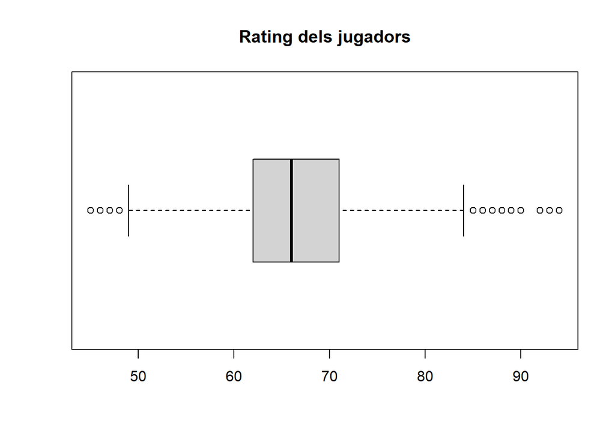

```r
boxplot(fifa$Rating, horizontal=TRUE, main="Rating dels jugadors")
```

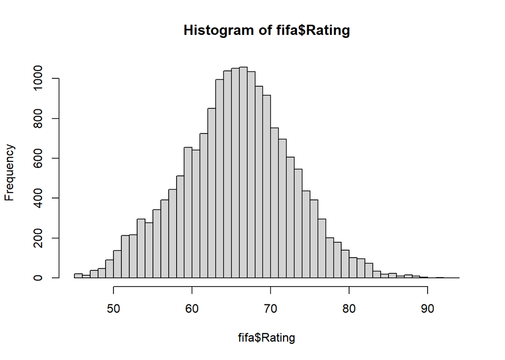

```r
hist(fifa$Rating, breaks=50)
```

Tant amb el boxplot com ara amb l’histograma podem concloure visualment que ens trobem amb una distribució normal.

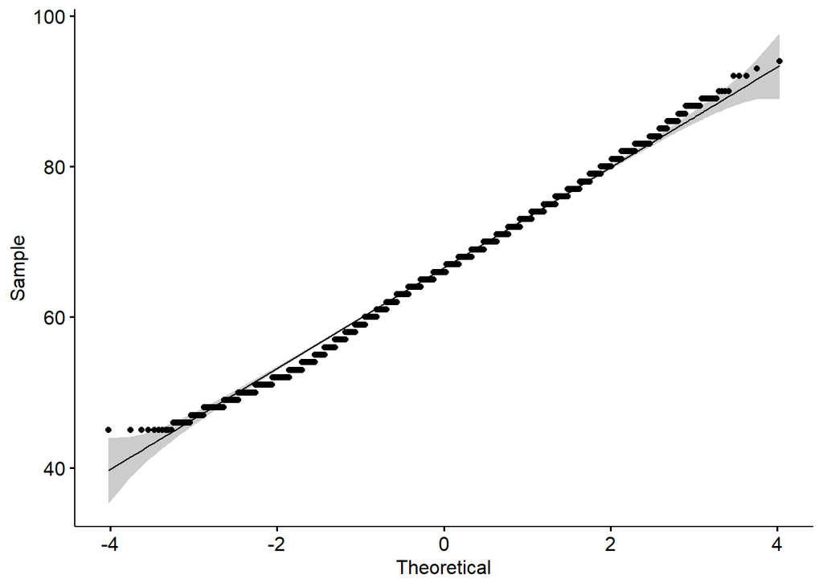

```r
ggqqplot(fifa$Rating)
```

Per acabar de comprovar-ho fem servir la funció ggqqplot https://es.wikipedia.org/wiki/Gr%C3%A1fico_Q-Q, on tenim una distribució exemple i la nostre. Com més aprop de la normalitat més sobreposada estarà una línea sobre l’altre. Els nostres punts fan una línea recta molt ben definida sobre la línea d’exemple.

## 2.2 Interval de confiança

Anem a calcular l’interval de confiança sobre l’atribut Rating.

### 2.2.1 Interval de confiança sobre la mitjana rating

En aquest cas, assumim com hem vist que la mostra segueix una distribució normal i tenim una desviació típica coneguda (realment no la tenim). Anem a calcular l’interval [L,U] tal que la probabilitat que z (un valor de la mostra) estigui en aquest interval sigui de 0.95.

Per calcular l’interval amb aquesta probabilitat necessitem el valor crític per al nivell de confiança del 95% que és α / 2. Aquest valor el càlculem amb la funció qnorm.

```r
qnorm(0.975)
```

```
## [1] 1.959964
```

Donem per fet que la desviació estandard és la de la mostra que tenim. Llavors per calcular els límits superior i inferior de l’interval:

`[mean - z * SE], [mean + z * SE], on SE = sd / √n`

```r
sd <- sd(fifa$Rating)
alfa <- 1- 0.95
n <- nrow(fifa)
SE <- sd / sqrt(n)
z <- qnorm(alfa/2, lower.tail=FALSE)
L <- mean(fifa$Rating) - z*SE
U <- mean(fifa$Rating) + z*SE
round(c(L,U), 2)
```

```
## [1] 66.06 66.27
```

Llavors, podem concloure que la mitjana de Rating amb un nivell de confiança de 95% és troba entre els valors 66.06 i 66.27.

### 2.2.2 Interval de confiança sobre la mitjana rating amb variància desconeguda.

Realment no tenim la variància de la mostra de Rating, per tant el que fem és trobar una estimació d’aquesta a partir de la mostra que tenim. En aquest cas, la variable segueix una distrobució de t d’Student amb n - 1 graus de llibertat on amb mides grans s’apropa a una distribució normal (n és el nombre d’elements de la mostra).

```r
alfa <- 1-0.95
sd <- sd(fifa$Rating)
n <- nrow(fifa)
SE <- sd / sqrt(n)
z <- qt(alfa/2, df=n-1, lower.tail=FALSE)
L <- mean(fifa$Rating) - z*SE
U <- mean(fifa$Rating) + z*SE
round( c(L,U), 2)
```

```
## [1] 66.06 66.27
```

Tenim el mateix valor que amb la desviació estandard calculada de la mostra.

Amb la funció t.test obtenim l’interval de confiança amb variable desconeguda també de forma automàtica.

```r
t.test(fifa$Rating, conf.level = 0.95)
```

```
##
##  One Sample t-test
##
## data:  fifa$Rating
## t = 1238.9, df = 17587, p-value < 2.2e-16
## alternative hypothesis: true mean is not equal to 0
## 95 percent confidence interval:
##  66.06151 66.27088
## sample estimates:
## mean of x
##  66.16619
```

# 3 Diferències entre jugadors

Volem saber sota una creença popular si els jugadors esquerrans tenen millor control de la pilota (Ball_Control), valoració (Rating) i dribbling (Dribbling) que els dretans.

Precondicions:

- Hem de treure els jugadors que no siguin de camp, es a dir, els porters.
- El control de la pilota el tenim al camp Preffered_Foot (Left o Right).
- El control de la pilota el tenim al camp Ball_Control.
- La valoració la tenim al camp Rating.
- El dribbling el tenim al camp Dribbling.
- Nivell de confiança del 95%.

Anem a seleccionar les dues mostres dels no-porters (jugadors de camp):

```r
# seleccionem els jugadors de camp
nrow(fifa)
```

```
## [1] 17588
```

```r
fifa.fieldplayer <- subset(fifa, fifa$Club_Position != 'GK')
nrow(fifa.fieldplayer)
```

```
## [1] 16956
```

```r
# comprovem que és correcte
summary(fifa.fieldplayer$Club_Position)
```

```
##       CAM   CB  CDM   CF   CM   GK  LAM   LB  LCB  LCM  LDM   LF   LM   LS   LW
##    1  315   83  119    4   79    0   36  549  631  354  266   12  414  205  133
##  LWB  RAM   RB  RCB  RCM  RDM  Res   RF   RM   RS   RW  RWB   ST  Sub
##   45   36  548  633  353  266 3146   12  414  206  133   45  426 7492
```

```r
# seleccionem els esquerrans i els dretans per grups
fifa.left <- subset(fifa.fieldplayer, fifa.fieldplayer$Preffered_Foot == 'Left')
fifa.right <- subset(fifa.fieldplayer, fifa.fieldplayer$Preffered_Foot == 'Right')

# comprovem que és correcte
summary(fifa.left$Preffered_Foot)
```

```
##  Left Right
##  4022     0
```

```r
summary(fifa.right$Preffered_Foot)
```

```
##  Left Right
##     0 12934
```

## 3.1 Pregunta d’investigació

Farem diverses preguntes d’investigació:

1. Tenen els jugadors esquerrans millor control de la pilota que els dretans?
2. Tenen els jugadors esquerrans millor valoració que els dretans?
3. Tenen els jugadors esquerrans millor dribbling que els dretans?

## 3.2 Representació visual

Anem a representar visualment cada una dels atributs en funció del peu amb el que juguen.

### 3.2.1 Ball_Control

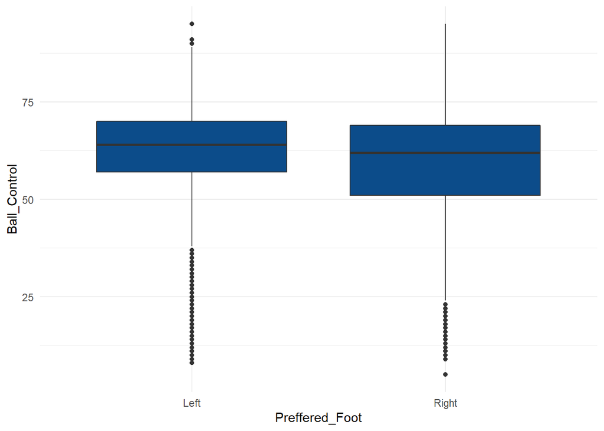

```r
ggplot(fifa) +
  aes(x = Ball_Control, y = Preffered_Foot) +
  geom_boxplot(fill = "#0c4c8a") +
  theme_minimal() +coord_flip()
```

Visualment, sí que sembla que els jugadors esquerrans siguin millors que els dretans en quant a control de pilota. Tant el Q1, Q3 i mediana són valors superiors. També ho sembla el valora mínim i màxim.

### 3.2.2 Rating

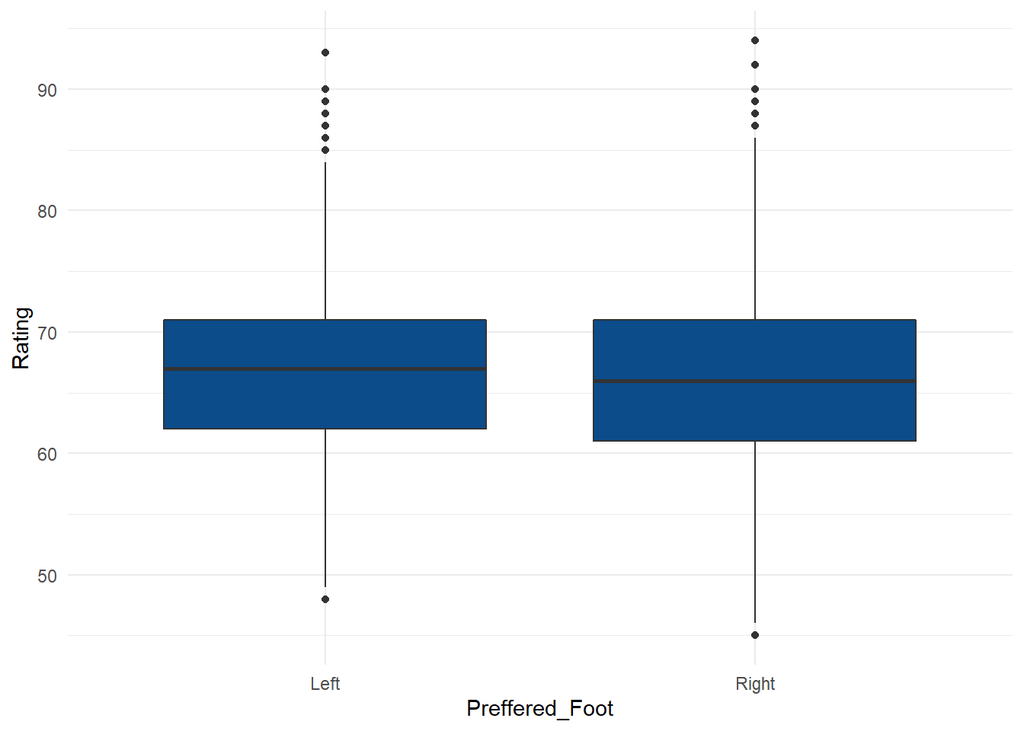

```r
ggplot(fifa) +
  aes(x = Rating, y = Preffered_Foot) +
  geom_boxplot(fill = "#0c4c8a") +
  theme_minimal() +coord_flip()
```

El mateix passa amb el camp Rating però potser no és tant evident.

### 3.2.3 Dribbling

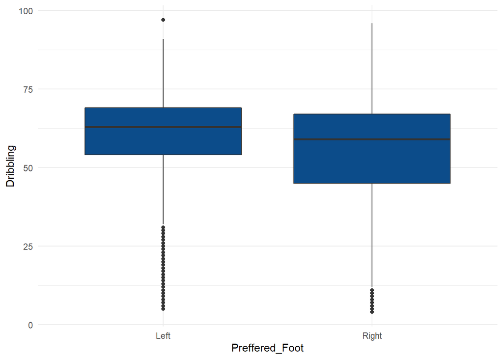

```r
ggplot(fifa) +
  aes(x = Dribbling, y = Preffered_Foot) +
  geom_boxplot(fill = "#0c4c8a") +
  theme_minimal() +coord_flip()
```

I finalment el Dribbling el mateix que amb les altres dues propietats. Visualment diria que efectivament sembla que els jugadors esquerrans tenen millor control de la pilota, valoració i dribbling que els dretans.

## 3.3 Hipòtesi nul·la i alternativa

Farem un contrast d’hipòtesi unilateral.

1. Control de pilota:
   - Hipòtesi nul·la: Ball_Control Jugadors esquerrans = Ball_Control jugadors dretans
   - Hipòtesi alternativa: Ball_Control Jugadors esquerrans > Ball_Control jugadors dretans
2. Valoració:
   - Hipòtesi nul·la: Rating Jugadors esquerrans = Rating jugadors dretans
   - Hipòtesi alternativa: Rating Jugadors esquerrans > Rating jugadors dretans
3. Dribbling:
   - Hipòtesi nul·la: Dribbling Jugadors esquerrans = Dribbling jugadors dretans
   - Hipòtesi alternativa: Dribbling Jugadors esquerrans > Dribbling jugadors dretans

## 3.4 Mètode

### 3.4.1 Una mostra o dues mostres? Si són dues, relacionades o indenpendents?

És un test d’hipòtesi de dues mostres, ja que estem comparant paràmetres de dues poblacions (jugadors dretans i jugadors esquerrans).

Las mostres son independents ja que els valors d’una mostra no afectan als valors de l’altre.

### 3.4.2 Podem assumir normalitat? Perquè?

Sí. Podem assumir normalitat ja que a partir del Teorem Central de Límit (TCL) podem dir que la mitjana de la mostra s’aproxima a una distribució normal quan el nombre d’elements està per sobre de 30 (n > 30). En el nostre cas, ambdues mostres estan molt per sobre de 30.

```r
# nombre d'elements de la mostra del peu esquerra
nrow(fifa.left)
```

```
## [1] 4022
```

```r
# nombre d'elements de la mostra del peu dret
nrow(fifa.right)
```

```
## [1] 12934
```

En el cas que no fos així, hauriem d’utilitzar un test de normalitat de dades com per exemple el de Shapiro-Wilk.

### 3.4.3 Test és paramètric o no?

Es tracta d’un test paramètric ja que estem assumint que les dades segueixen una determinada distribució, en aquest cas distribució normal o més concretament t de Student ja que la variància de les mostres l’haurem d’inferir.

### 3.4.4 Bilateral o unilateral?

Com hem comentat, donada la nostre hipòtesi alternativa és tracta d’un test unilateral. Per a rebutjar la hipòtesi nul·la cal observar un valor superior en els jugadors esquerrans que en els dretans.

### 3.4.5 És pot assumir homocedasticitat o heterocedasticitat?

Les variàncies són desconegudes però similars quan podem assumir homocedasticitat, quan són diferents diem que podem assumir heterocedasticitat.

Saber quin tipus de variàncies tenim anem a realitzar el **test d’igualtat de variàncies**.

Hem d’aplicar el test d’igualtat de variàncies:

- Ho: σ²₁ = σ²₂
- H1: σ²₁ ≠ σ²₂

Calculem els valors de les variançes mostrals i calculem el valor observat a partir de la distribució F d’Snedecor.

Crearem una funció que realitzarà els càlculs per a les tres variables:

```r
vtype <- function(left, right) {

    # el nivell de confiança és del 95% per tant tenim una alpha de 0.05 (P=0.95)
    alfa <- 0.05

    # calculem les desviacions de les mostres
    sd1 <- sd(left)
    sd2 <- sd(right)

    # calculem les mitjes de les mostres
    mean1 <- mean(left)
    mean2 <- mean(right)

    # elements de les mostres
    n1 <- length(left)
    n2 <- length(right)

    # valor observat de la mostra
    fobs <- sd1^2 / sd2^2
    cat("El valor observat és:", fobs, "\n")

    # llindar inferior de la zona d'acceptació
    fcritL <- qf(alfa/2, df1=n1-1, df2=n2-2)
    cat("El llindar inferior és:", fcritL, "\n")

    # llindar superior de la zona d'acceptació
    fcritU <- qf(1 - alfa/2, df1=n1-1, df2=n2-2)
    cat("El llindar superior és:", fcritU, "\n")

    # calculem la probabilitat d'obtenir el valor observat assumint que la hipòtesi nul·la és certa. Si p < alpha, podem rebutjar la hipòtesi nul·la.
    pvalue <- min(pf(fobs, df1=n1-1, df2=n2-2, lower.tail=FALSE ), pf(fobs, df1=n1-1, df2=n2-2))*2
    cat("El valor de p és:", pvalue, "\n")

}
```

#### 3.4.5.1 Ball_Control

```r
vtype(fifa.left$Ball_Control, fifa.right$Ball_Control)
```

```
## El valor observat és: 0.5909475
## El llindar inferior és: 0.9508611
## El llindar superior és: 1.050977
## El valor de p és: 1.122406e-85
```

El valor observat és de 0.5909475 que no és troba en la zona d’acceptació [0.9508611, 1.050977], això fà que rebitjem la hipòtesi nul·la i concloem que tenim heterocedasticitat.

Anàlogament hem càlculat la p que és molt per sota de l’alfa i per tant també ens indica que no acceptarem la hipòtesi nul·la.

Farem els mateix procediment per Rating i Dribbling. Repetirem alguns càlculs que realment no caldrien (alfa, n1, n2, fcritL i fcritU), ja que depenen de n1 i n2 i aquests són els mateixos.

#### 3.4.5.2 Rating

```r
vtype(fifa.left$Rating, fifa.right$Rating)
```

```
## El valor observat és: 0.8456888
## El llindar inferior és: 0.9508611
## El llindar superior és: 1.050977
## El valor de p és: 1.037705e-10
```

Passa exactament el mateix que amb Ball_Control. Valor observat cau per sota de la zona d’acceptació que ja sabiem que era [0.9508611, 1.050977], encara que tal i com havíem vist a l’anàlisi visual no és tant evident.

#### 3.4.5.3 Dribbling

```r
vtype(fifa.left$Dribbling, fifa.right$Dribbling)
```

```
## El valor observat és: 0.6269791
## El llindar inferior és: 0.9508611
## El llindar superior és: 1.050977
## El valor de p és: 1.243947e-68
```

I finalment, el mateix amb Dribbling. Valor observat = 0.6269791 < [0.9508611, 1.050977] => heterocedasticitat. El p-valor està molt per sota del valor alfa que és 0.05 per tant ens confirma aquesta no acceptació de la hipòtesi nul·la.

### 3.4.6 Resum

Tenim doncs per a cada un dels test d’hipòtesi que hem de realitzar:

- Dues mostres independents.
- Assumim distribucions normals.
- Variances desconegudes.
- Heterocedasticitat.
- Test unilateral.
- Test paramètric.

## 3.5 Càlculs

Anem a realitzar els càlculs per a resoldre les preguntes d’investigació a partir dels test d’hipòtesi. L’estadístic segueix una distribució t de Student en lloc de la distribució normal ja que hem d’estimar les variançes a partir de les mostres.

### 3.5.1 Function

Montem una funció per a generalitzar els càlculs

```r
f2 <- function(left, right) {

  results <- NULL

  # càlculs de mean, n i s
  mean_Left <- mean(left)
  cat("mean_Left és:", mean_Left, "\n")
  results$mean_Left <- mean_Left

  mean_Right <- mean(right)
  cat("mean_Right és:", mean_Right, "\n")
  results$mean_Right <- mean_Right

  n_Left <- length(left)
  cat("n_Left és:", n_Left, "\n")
  results$n_Left <- n_Left

  n_Right <- length(right)
  cat("n_Right és:", n_Right, "\n")
  results$n_Right <- n_Right

  s_left <- sd(left)
  cat("s_left és:", s_left, "\n")
  results$s_left <- s_left

  s_right <- sd(right)
  cat("s_right és:", s_right, "\n")
  results$s_right <- s_right

  # estadístic de contrast
  obs_value <- (mean_Left - mean_Right) / (sqrt((s_left^2 / n_Left) + (s_right^2 / n_Right)))
  cat("L'estadístic de contrast o valor observat és:", round(obs_value, 3), "\n")
  results$obs_value <- obs_value

  # graus de llibertat
  v <- ((s_left^2 / n_Left) + (s_right^2 / n_Right))^2 / (((s_left^2 / n_Left)^2 / (n_Left - 1)) + ((s_right^2 / n_Right)^2 / (n_Right - 1)))
  cat("Els graus de llibertat són:", round(v,1), "\n")
  results$v <- v

  # valor crític on rebutjem la H0 en favor de la alternativa.
  # com volem la part superior de la corva, fem lower.tail = FALSE
  critical <- qt(0.005, lower.tail = FALSE, df=round(v,1)-1)
  cat("La regió d'acceptació de la hipòtesi nul·la està entre ( -infinit,", critical, "]\n")
  results$critical <- critical

  # Càlcul del valor pvalue
  pvalue <- pt(obs_value, lower.tail = FALSE, df=round(v,1)-1)
  cat("La probabilitat de que rebutjar la hipòtesi sigui incorrecte és:", pvalue, "]\n")
  results$pvalue <- pvalue


  return <- results
}
```

### 3.5.2 Ball_Control

```r
ball_control.results <- f2(fifa.left$Ball_Control, fifa.right$Ball_Control)
```

```
## mean_Left és: 62.16335
## mean_Right és: 58.47727
## n_Left és: 4022
## n_Right és: 12934
## s_left és: 12.46384
## s_right és: 16.21353
## L'estadístic de contrast o valor observat és: 15.182
## Els graus de llibertat són: 8623.8
## La regió d'acceptació de la hipòtesi nul·la està entre ( -infinit, 2.5764 ]
## La probabilitat de que rebutjar la hipòtesi sigui incorrecte és: 1.07212e-51 ]
```

El valor observat està per sobre de la zona d’acceptació, per tant rebutjem la hipòtesi nul·la. Anàlogament el valor de p-valor és inferior a 0.05, l’error que cometriem en rebutjar la hipòtesi nul·la de forma incorrecta és molt petit.

Fem el càlcul amb la funció t.test:

```r
t.test(fifa.left$Ball_Control, fifa.right$Ball_Control,alternative="greater", var.equal=FALSE)
```

```
##
##  Welch Two Sample t-test
##
## data:  fifa.left$Ball_Control and fifa.right$Ball_Control
## t = 15.182, df = 8623.8, p-value < 2.2e-16
## alternative hypothesis: true difference in means is greater than 0
## 95 percent confidence interval:
##  3.286679      Inf
## sample estimates:
## mean of x mean of y
##  62.16335  58.47727
```

### 3.5.3 Rating

```r
rating.results <- f2(fifa.left$Rating, fifa.right$Rating)
```

```
## mean_Left és: 66.58155
## mean_Right és: 65.8582
## n_Left és: 4022
## n_Right és: 12934
## s_left és: 6.610617
## s_right és: 7.188474
## L'estadístic de contrast o valor observat és: 5.934
## Els graus de llibertat són: 7218.3
## La regió d'acceptació de la hipòtesi nul·la està entre ( -infinit, 2.576511 ]
## La probabilitat de que rebutjar la hipòtesi sigui incorrecte és: 1.548782e-09 ]
```

El valor observat 5.934 de l’estadístic de contrast està per sobre de la zona d’acceptació, per tant rebutjem la hipòtesi nul·la. A més el p-value és molt inferior al nivell de significança.

Fem el càlcul amb la funció t.test:

```r
t.test(fifa.left$Rating,fifa.right$Rating, alternative="greater", var.equal=FALSE)
```

```
##
##  Welch Two Sample t-test
##
## data:  fifa.left$Rating and fifa.right$Rating
## t = 5.9338, df = 7218.3, p-value = 1.549e-09
## alternative hypothesis: true difference in means is greater than 0
## 95 percent confidence interval:
##  0.5228087       Inf
## sample estimates:
## mean of x mean of y
##  66.58155  65.85820
```

### 3.5.4 Dribbling

```r
dribbling.results <- f2(fifa.left$Dribbling, fifa.right$Dribbling)
```

```
## mean_Left és: 60.15266
## mean_Right és: 55.09688
## n_Left és: 4022
## n_Right és: 12934
## s_left és: 14.45337
## s_right és: 18.25335
## L'estadístic de contrast o valor observat és: 18.138
## Els graus de llibertat són: 8359.4
## La regió d'acceptació de la hipòtesi nul·la està entre ( -infinit, 2.576418 ]
## La probabilitat de que rebutjar la hipòtesi sigui incorrecte és: 1.923789e-72 ]
```

```r
t.test(fifa.left$Dribbling,fifa.right$Dribbling, alternative="greater", var.equal=FALSE)
```

```
##
##  Welch Two Sample t-test
##
## data:  fifa.left$Dribbling and fifa.right$Dribbling
## t = 18.138, df = 8359.4, p-value < 2.2e-16
## alternative hypothesis: true difference in means is greater than 0
## 95 percent confidence interval:
##  4.597236      Inf
## sample estimates:
## mean of x mean of y
##  60.15266  55.09688
```

En els tres cassos és rebutja la hipòtessi nul·la en favor de la alternativa amb el que concluim que els jugadors esquerrans tenen millor Ball_Control, Rating i Dribbling que els dretans.

## 3.6 Taula de resultats

```r
mean_Left <- c(ball_control.results$mean_Left, rating.results$mean_Left, dribbling.results$mean_Left)

mean_Right <- c(ball_control.results$mean_Right, rating.results$mean_Right, dribbling.results$mean_Right)

n_Left <- c(ball_control.results$n_Left, rating.results$n_Left, dribbling.results$n_Left)

n_Right <- c(ball_control.results$n_Right, rating.results$n_Right, dribbling.results$n_Right)

obs_value <- c(ball_control.results$obs_value, rating.results$obs_value, dribbling.results$obs_value)

critical <- c(ball_control.results$critical, rating.results$critical, dribbling.results$critical)

pvalue <- c(ball_control.results$pvalue, rating.results$pvalue, dribbling.results$pvalue)

out <- data.frame( var=c("BallControl", "Rating",  "Dribbling"),
mean_Left=mean_Left,
mean_Right=mean_Right,
n_Left=n_Left,
n_Right=n_Right,
obs_value=obs_value,
critical=critical,
pvalue=pvalue)

out %>% kable() %>% kable_styling()
```

| var | mean_Left | mean_Right | n_Left | n_Right | obs_value | critical | pvalue |
| --- | --- | --- | --- | --- | --- | --- | --- |
| BallControl | 62.16335 | 58.47727 | 4022 | 12934 | 15.181923 | 2.576400 | 0 |
| Rating | 66.58155 | 65.85820 | 4022 | 12934 | 5.933765 | 2.576511 | 0 |
| Dribbling | 60.15266 | 55.09688 | 4022 | 12934 | 18.137562 | 2.576418 | 0 |

## 3.7 Interpretació

Durant l’exercici 3 hem anat veient les conclusions a la creença popular de que els jugadors esquerrans tenen millor control de la pilota, valoració i dribbling. Efectivament a nivell numèric sembla que de mitjana aquests jugadors tenen millor valors.

Posteriorment hem aplicat els test d’hipòtesi on en els tres casos hem rebutjat la hipòtesi nul·la d’igualtat de mitjanes en favor de la hipòtesi nul·la de mitjana del jugadors de domini de la pilota amb peu esquerra superior als del peu dret. En tots el casos l’error que es cometria en rebutjar la hipòtesi nul·la si aquesta fos certa és ínfim.

# 4 Comparació per parells

Volem saber si obtindriem els mateixos resultats comparant els jugadors de camp esquerrans amb els dretans que tinguin un pes, alçada i edat similar. Farem servir el procés Propensity score matching.

## 4.1 Jugador més similar

Anem a buscar els jugadors més similars en termes d’alçada, pes i edat dels jugadors dretans i esquerrans. Fem servir un algoritme de distància per a trobar les semblançes.

Primer agafarem dues mostres més reduïdes, ja que els càlculs per trobar els similars és costós.

```r
# primer agafem una mostra aleatòria de 100 dels jugadors esquerrans i després de 200 per els esquerrans

nrow(fifa.left)
```

```
## [1] 4022
```

```r
random.left <- sample(1:nrow(fifa.left), 100)
left.sample <- fifa.left[random.left,]
nrow(left.sample)
```

```
## [1] 100
```

```r
nrow(fifa.right)
```

```
## [1] 12934
```

```r
random.right <- sample(1:nrow(fifa.right), 200)
right.sample <- fifa.right[random.right,]
nrow(right.sample)
```

```
## [1] 200
```

```r
head(left.sample)
```

```
##          ID             Name Nationality National_Position National_Kit
## 11772 11772      Gerald Nutz     Austria              <NA>           NA
## 14895 14895      Luis Chávez      Mexico              <NA>           NA
## 965     965 Anderson Talisca      Brazil              <NA>           NA
## 8023   8023 Dorian Dessoleil     Belgium              <NA>           NA
## 3530   3530      Bruno Uvini      Brazil              <NA>           NA
## 3128   3128             Momo       Spain              <NA>           NA
##                 Club Club_Position Club_Kit Club_Joining Contract_Expiry Rating
## 11772 Wolfsberger AC           Sub       29   2016-07-04            2018     63
## 14895        Tijuana           Res       24   2013-07-01            2023     59
## 965         Besiktas           CAM       94   2014-07-08            2019     77
## 8023   Sp. Charleroi            CB       24   2015-07-01            2022     67
## 3530        Al Nassr           LCB        2   2016-08-08            2019     72
## 3128   UD Las Palmas           Sub       11   2012-02-01            2017     73
##       Height Weight Preffered_Foot Birth_Date Age Preffered_Position
```

[output cut: 48 more lines]

Montem les funcions euclidean, my.nn i my.nn.sample

```r
# com més propers més aprop de 0
euclidean <- function(x1, x2){
  return (sqrt(sum((x1-x2)^2)))
}

# funció per trobar el valor mes proper al jugador x en el dataset sample (jugadors dretans)
my.nn <- function(x, right) {

  # inicialitzem amb el primer valor i la primera distància
  nearest <- 1

  # calculem la distancia del primer
  distance <- euclidean(x, select(right[1,], Height, Weight, Age))

  # iterem per trobar el més proper
  for (i in 2:dim(right)[1]) {
    new_distance <-  euclidean(x, select(right[i,], Height, Weight, Age))
    if (distance > new_distance) {
      nearest <- i
      distance <- new_distance

      # si la distancia és 0, no seguim
      if (distance == 0)  break
    }
  }
  return <- right[nearest,]
}

# funció per trobar tots el jugadors esquerrans més propers als dretans
my.nn.sample <- function(left.sample, right.sample){

  # creem un dataframe buït amb el header de l'original (pot ser left.sample o right.sample)
  right.paired <- data.frame()

  for (i in 1:dim(left.sample)[1]) {

    # afagem només els atributs per calcular la distància
    left.element <- select(left.sample[i,], Height, Weight, Age)

    # busquem el més proper dels esquerrans
    nearest <- my.nn(left.element, right.sample)

    # afeim al nou dataset
    right.paired <- rbind(right.paired, nearest)
  }
  return <- right.paired
}
```

On cop creades les 3 funcions anem a executar el procés.

```r
right.paired <- my.nn.sample(left.sample, right.sample)
```

## 4.2 Mostres

```r
# primers elements de right.paired
head(select(right.paired, Height, Weight, Age))
```

```
##       Height Weight Age
## 4771     170     65  21
## 9650     178     72  21
## 5241     191     80  25
## 12942    186     70  23
## 11034    185     84  23
## 1999     180     70  34
```

```r
# primers elements de left.sample
head(select(left.sample, Height, Weight, Age))
```

```
##       Height Weight Age
## 11772    170     64  22
## 14895    179     73  20
## 965      191     80  22
## 8023     184     68  24
## 3530     186     83  25
## 3128     180     70  34
```

Un cop tenim les mostres

## 4.3 Hipòtesi nul·la i alternativa

Podem veure visualment amb un gràfic bloxplot si el Rating d’aquestes dues mostres (jugadors dretans i esquerrans més similars) tenen una variació en la mediana, Q1, Q3, màxim i mínim.

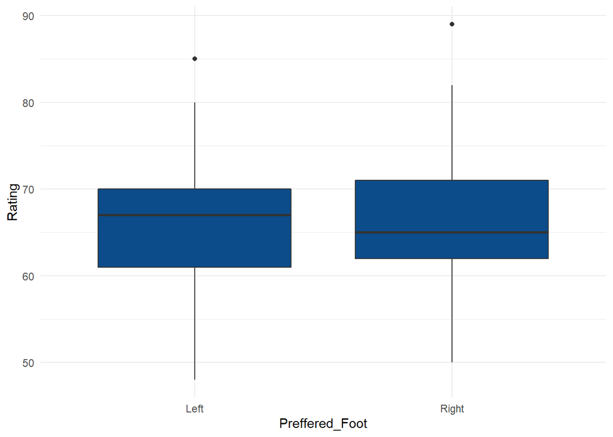

```r
right.left <- rbind(right.paired, left.sample)

ggplot(right.left) +
  aes(x = Rating, y = Preffered_Foot) +
  geom_boxplot(fill = "#0c4c8a") +
  theme_minimal() +coord_flip()
```

El que realitzarem és un test d’hipòtesi però amb les mostres aparellades, aquestes mostres no són aleatòries com en l’exercici anterior. Tenen una relació de dependència on la mostra dels dretans és en relació a la semblança en alçada, pes i edat als esquerrans.

- Hipòtesi nul·la: els jugadors esquerrant són similars en Rating als jugadors similars en pes alçada i edat dels dretans.
- Hipòtesi alternativa: els jugadors esquerrans són millors en Rating als jugadors similars en ped, alçada i edat dels dretans.

## 4.4 Mètode

El mètode que aplicarem és:

- Assumim distribució normal ja que les mostres tenen més de 30 elements.
- Dues mostres aparellades. Les mostres no són aleatories sino que una és depenent de l’altre en funció de l’alçada, pes i edat dels jugadors.
- Com no coneixem la variança de la població aplicarem t d’Student amb n-1 graus de llibertat.
- Test unilateral:
  - Ho: µd = 0 -> la diferència de mitjanes és 0. Això vol dir que no hi ha diferència de Rating
  - H1: µd > 0 -> la diferència és más gran de 0. Els Rating dels esquerrans és millor que els dretans.
- Test paramètric.
- Homocedasticitat o heterocedasticitat:

Aplicarem la funció de l’apartat anterior vtype.

```r
vtype(right.paired$Rating, left.sample$Rating)
```

```
## El valor observat és: 1.084102
## El llindar inferior és: 0.6722911
## El llindar superior és: 1.488054
## El valor de p és: 0.6896883
```

El valor observat està dins la zona d’acceptació. A més pvalue està molt per sobre de 0.05 amb el que no podem rebutjar la hipòtesi nul·la i hem de deduïr homocedasticitat. Les variancies són iguals.

## 4.5 Càlculs

Calcularem la diferència entre els Rating dels jugadors esquerrans i els jugadors dretans.

```r
difference <- left.sample$Rating - right.paired$Rating
difference
```

```
##   [1]  -7  -6   7   5   8  -2  -1  -2  -3   2  -2   2 -10  -2 -18   4  -2   0
##  [19]   4   2   7  -4   2   8   1   6   1 -13   4  -2   5  -9  -1   1  -4   9
##  [37]  -3   3  -5   3   5  -4   4  -5  -4  -7  22  -2 -12   8   6  -7 -14   9
##  [55]   4   6  -2 -11   3 -23  -4   3   0  15 -11   1  -5   3  -6   7  -7  -1
##  [73]   5  -2 -11 -12  10   3   3   0  -1 -20  -9  16 -11  10 -10   4   9   2
##  [91]   6  -4   0   1  -2   9  14   8  -2   7
```

Apliquem el test d’hipòtesi entre les dues mostres:

```r
# calculem la mitja de les diferències de les mostres
mean.difference <- mean(difference)

# desviació estandard de les diferències de les mostres
sd.difference <- sd(difference)

# nombre d'elements de la diferencia
n.difference <- length(difference)

# calculem el valor observat
obs_value <- (mean.difference) / (sd.difference / sqrt(n.difference))
cat("L'estadístic de contrast o valor observat és:", round(obs_value, 3), "\n")
```

```
## L'estadístic de contrast o valor observat és: -0.235
```

```r
# graus de llibertat
df <- n.difference - 1
cat("Els graus de llibertat són:", round(df,1), "\n")
```

```
## Els graus de llibertat són: 99
```

```r
# valor crític on rebutjem la H0 en favor de la alternativa.
# com volem la part superior de la corva, fem lower.tail = FALSE
critical <- qt(0.005, lower.tail = FALSE, df=round(df-1))
cat("La regió d'acceptació de la hipòtesi nul·la està entre ( -infinit,", critical, "]\n")
```

```
## La regió d'acceptació de la hipòtesi nul·la està entre ( -infinit, 2.626931 ]
```

```r
# Càlcul del valor pvalue
pvalue <- pt(obs_value, lower.tail = FALSE, df=round(df-1))
cat("La probabilitat de que rebutjar la hipòtesi sigui incorrecte és:", pvalue, "]\n")
```

```
## La probabilitat de que rebutjar la hipòtesi sigui incorrecte és: 0.5925682 ]
```

Fem el mateix càlcul però amb la funció d’R t.test

```r
t.test(left.sample$Rating, right.paired$Rating, paired=TRUE, alternative="greater")
```

```
##
##  Paired t-test
##
## data:  left.sample$Rating and right.paired$Rating
## t = -0.23479, df = 99, p-value = 0.5926
## alternative hypothesis: true difference in means is greater than 0
## 95 percent confidence interval:
##  -1.45294      Inf
## sample estimates:
## mean of the differences
##                   -0.18
```

## 4.7 Reflexió

Amb mostres totalment aleatories, els càlculs ens deien que el Rating era millor en els esquerrans que els dretans. En canvi, si agafem mostres aparellades en similitud física la hipòtesi inicial no és compleix.

Per tant, amb aquestes dades no podria dir que els jugadors esquerrans siguin millor que els dretans quan aquests són físicament similars. En un conjunt global si que sembla que els jugadors esquerrans són millors que els dretans (exercici 3) però quan condicionem aquest test a uns altres atributs deixa de tenir vigència aquesta idea inicial.

Aquest tipus de comparació ens podria ser útils si per exemple fossim captadors de nous talents i volguèssim cercar nous jugadors de qualitat. Realment no buscariem jugadors que fossin dretans o esquerrans sinó que tinguessin certes condicions físiques.

# 5 Comparació entre clubs

Anem a comparar la qualitat dels jugadors entre el FC Barcelona i el Madrid. Concretament volem saber si el percentatge de jugadors amb Rating > 90 és igual o diferent entre el Barcelona i el Madrid amb un nivell de confiança del 97%.

## 5.1 Hipòtesi nul·la i alternativa

- Hipòtesi nul·la: la proporció de jugadors amb Rating > 90 del Barcelona és igual a la proporció del Madrid.
- Hipòtesi alternativa: la proporció de jugadors amb Rating > 90 del Barcelona és diferent a la proporció del Madrid.

## 5.2 Mètode

Aplicarem un test bilateral (volem saber si són iguals o diferents) de dues mostres sobre la proporció assumint que les dues mostres són grans.

## 5.3 Càlculs

Seleccionem els grups de jugadors del Barça i del Madrid

```r
barcelona.players <- subset(fifa, fifa$Club == 'FC Barcelona')
madrid.players <- subset(fifa, fifa$Club == 'Real Madrid')
```

Calculem les proporcions de jugadors amb Rating > 90

```r
p1 <- sum(barcelona.players$Rating > 90) / nrow(barcelona.players)
p1
```

```
## [1] 0.09090909
```

```r
p2 <- sum(madrid.players$Rating > 90) / nrow(madrid.players)
p2
```

```
## [1] 0.03030303
```

Calculem la mitja de les proporcions, el valor observat, el valor crític i el p-valor :

```r
# nombre d'elements de les mostres
n1 <- nrow(barcelona.players)
n2 <- nrow(madrid.players)

# mitja de les proporcions
p <- (n1*p1 + n2*p2) / (n1+n2)
cat("La mitja de la proporció de les mostres és: ", round(p, 3), "\n")
```

```
## La mitja de la proporció de les mostres és:  0.061
```

```r
# valor observat
zobs <- (p1 - p2)/(sqrt(p * (1 - p) * ((1/n1) + (1/n2)) ))
cat("El valor observat és: ", round(zobs, 3), "\n")
```

```
## El valor observat és:  1.032
```

```r
# valor crític on rebutjem la H0 en favor de la alternativa.
zcrit <- qnorm(0.03, lower.tail = FALSE)
cat("El valor crític és:", round(zcrit, 3), "\n")
```

```
## El valor crític és: 1.881
```

```r
# Càlcul del valor pvalue
pvalue <- pnorm(zobs, lower.tail = FALSE)
cat("El pvalor és:", round(pvalue, 3), "\n")
```

```
## El pvalor és: 0.151
```

## 5.4 Resultats i interpretació

Amb aquests resultats no podem rebutjar la hipòtesi nul·la. El valor crític és 1.881 i el valor observat és 1.032 caient dins de la zona d’acceptació de la H0. A més, el valor del pvalue no és inferior a 0.03. Per tant, no podem dir que la proporció de jugadors amb Rating > 90 sigui diferent entre els jugadors del R. Madrid i el Barcelona.

# 6 Resum executiu

Anem a resumir una mica els anàlisi inferencials que hem anat fent en els diferents exercicis.

- Interval de confiança de la variable Rating:

Podem dir amb un vivell de confiança del 95% que la mitjana de Rating es troba entre els valors [66.06 66.27].

- Diferències entre els jugadors:

També podem dir, amb un nivell de confiança del 95%, que els jugadors esquerrans tenen millor dribbling, valoració i control de pilota que els jugadors dretans.

- Comparació per parells:

En canvi, quan relacionem els jugadors esquerrans amb els dretans per similitud física, amb un nivell de confiança del 95%, això canvia. NO podem dir que els jugadors esquerrans amb físic similar tinguin millor Rating que els dretans.

- Comparació entre clubs: